# Assignment 9: DonorsChoose_RF_GBDT

### SET3

- Reducing n_estimators and max_depth as using all leading to crash of programme

```python
train_auc = []
cv_auc = []

n_estimators = [50, 100, 200, 500]
max_depth = [2, 3, 4, 5, 6, 7, 8]

for i in n_estimators:
    train_temp = []
    cv_temp = []
    for j in max_depth:
        xgb = XGBClassifier(max_depth=j,n_estimators=i)
        xgb.fit(set3,y_train)

        y_train_pred = xgb.predict(set3)
        y_cv_pred = xgb.predict(set3_v)


        train_temp.append(roc_auc_score(y_train,y_train_pred))
        cv_temp.append(roc_auc_score(y_val, y_cv_pred))
    print("Completed = {}".format(i))
    train_auc.append(train_temp)
    cv_auc.append(cv_temp)
```

```
Completed = 50
Completed = 100
Completed = 200
Completed = 500
```

**Heatmap**

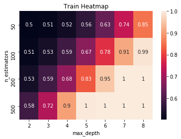

```python
Plot_heatmap(train_auc,"Train Heatmap")
```

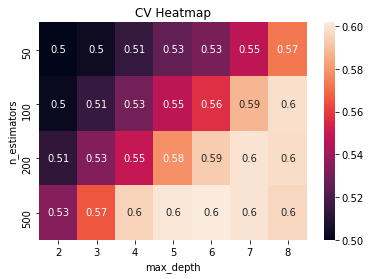

```python
Plot_heatmap(cv_auc,"CV Heatmap")
```

**AUC Plot**

```python
# probabilities calcultion
xgb = XGBClassifier(max_depth=3,min_child_weight=4,n_estimators=100)
xgb.fit(set3,y_train)
y1_predict_prob = xgb.predict_proba(set3_t)[:,1]
y1_predict_prob_train = xgb.predict_proba(set3)[:,1]

# took referance from https://stackoverflow.com/questions/25009284/how-to-plot-roc-curve-in-python
#fpr,tpr
fpr,tpr,thre = roc_curve(y_test,y1_predict_prob)

# am i doing it right here......?
fpr_train,tpr_train,thre_train = roc_curve(y_train,y1_predict_prob_train)
```

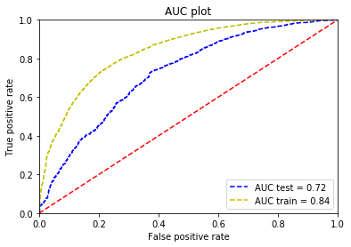

```python
# auc calculation for test data
roc_auc3 = metrics.auc(fpr,tpr)

# auc calculation for train data
roc_auc_train3 = metrics.auc(fpr_train,tpr_train)

# took referance from https://stackoverflow.com/questions/25009284/how-to-plot-roc-curve-in-python
plt.plot(fpr,tpr,"b--",label = 'AUC test = %0.2f'%roc_auc3)
plt.plot(fpr_train,tpr_train,"y--",label = 'AUC train = %0.2f'%roc_auc_train3)
plt.title("AUC plot")
plt.xlabel("False positive rate")
plt.ylabel("True positive rate")
plt.plot([0, 1], [0, 1],'r--')
plt.xlim([0,1])
plt.ylim([0,1])
plt.legend(loc = "lower right")
plt.show()
```

**Confusion Matrix**

1. Train Data

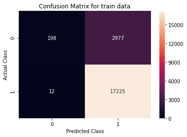

```python
y3_train_predict = xgb.predict(set3)
cm3 = confusion_matrix(y_train,y3_train_predict)
# https://seaborn.pydata.org/generated/seaborn.heatmap.html
cf_matrix(cm3,"train data")
```

1. Test Data

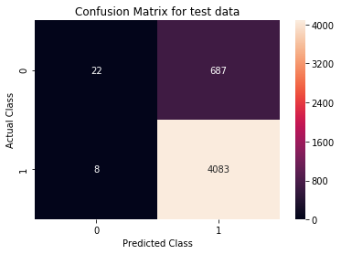

```python
y3_predict = xgb.predict(set3_t)
cm3 = confusion_matrix(y_test,y3_predict)
# https://seaborn.pydata.org/generated/seaborn.heatmap.html
cf_matrix(cm3,"test data")
```

### Set 4

- Reducing n_estimators and max_depth as using all leading to crash of programme

```python
train_auc = []
cv_auc = []

n_estimators = [50, 100, 200, 500]
max_depth = [2, 3, 4, 5, 6, 7, 8]

for i in n_estimators:
    train_temp = []
    cv_temp = []
    for j in max_depth:
        xgb = XGBClassifier(max_depth=j,n_estimators=i)
        xgb.fit(set4,y_train)

        y_train_pred = xgb.predict(set4)
        y_cv_pred = xgb.predict(set4_v)


        train_temp.append(roc_auc_score(y_train,y_train_pred))
        cv_temp.append(roc_auc_score(y_val, y_cv_pred))
    print("Completed = {}".format(i))
    train_auc.append(train_temp)
    cv_auc.append(cv_temp)
```

```
Completed = 50
Completed = 100
Completed = 200
Completed = 500
```

**Heatmap**

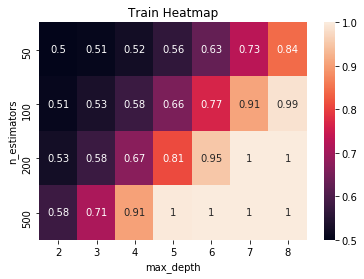

```python
Plot_heatmap(train_auc,"Train Heatmap")
```

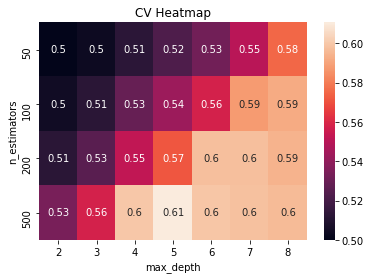

```python
Plot_heatmap(cv_auc,"CV Heatmap")
```

**AUC Plot**

```python
# probabilities calcultion
xgb = XGBClassifier(max_depth=3,in_child_weight=4,n_estimators=100)
xgb.fit(set4,y_train)
y1_predict_prob = xgb.predict_proba(set4_t)[:,1]
y1_predict_prob_train = xgb.predict_proba(set4)[:,1]

# took referance from https://stackoverflow.com/questions/25009284/how-to-plot-roc-curve-in-python
#fpr,tpr
fpr,tpr,thre = roc_curve(y_test,y1_predict_prob)

# am i doing it right here......?
fpr_train,tpr_train,thre_train = roc_curve(y_train,y1_predict_prob_train)
```

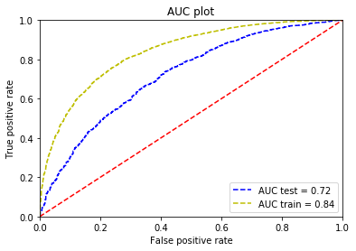

```python
# auc calculation for test data
roc_auc4 = metrics.auc(fpr,tpr)

# auc calculation for train data
roc_auc_train4 = metrics.auc(fpr_train,tpr_train)

# took referance from https://stackoverflow.com/questions/25009284/how-to-plot-roc-curve-in-python
plt.plot(fpr,tpr,"b--",label = 'AUC test = %0.2f'%roc_auc4)
plt.plot(fpr_train,tpr_train,"y--",label = 'AUC train = %0.2f'%roc_auc_train4)
plt.title("AUC plot")
plt.xlabel("False positive rate")
plt.ylabel("True positive rate")
plt.plot([0, 1], [0, 1],'r--')
plt.xlim([0,1])
plt.ylim([0,1])
plt.legend(loc = "lower right")
plt.show()
```

**Confusion Matrix**

1. Train Data

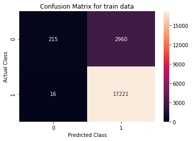

```python
y4_train_predict = xgb.predict(set4)
cm1 = confusion_matrix(y_train,y4_train_predict)
# https://seaborn.pydata.org/generated/seaborn.heatmap.html
cf_matrix(cm1,"train data")
```

1. Test Data

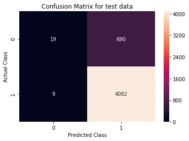

```python
y4_predict = xgb.predict(set4_t)
cm1 = confusion_matrix(y_test,y4_predict)
# https://seaborn.pydata.org/generated/seaborn.heatmap.html
cf_matrix(cm1,"test data")
```

### Obseravtion:

================

1. **max_depth** found to be most important parameter in tuning xgboost
2. For given max_depth and min_child_weight increase in n_estimators was leading to overfitting the model.
3. Tuning Avg-W2V and TFIDF-W2V took more time as compared to others.

### Summary

```python
from prettytable import PrettyTable
summary = PrettyTable()
```

```python
summary.field_names = ["Set", "Vectorizer", "Model", "Hyperparameter","Test","Train"]
```

```python
summary.add_row(["set1","BOW","XGBOOST","max_depth = 4,min_child_weight = 4,n_estimators = 100",0.74,0.84])
summary.add_row(["set2","TFIDF","XGBOOST","max_depth=4,min_child_weight = 4,n_estimators=100",0.74,0.86])
summary.add_row(["set3","Avg-W2v","XGBOOST","max_depth=3,min_child_weight = 4,n_estimators=100",0.72,0.84])
summary.add_row(["set4","TFIDF W2V","XGBOOST","max_depth=3,min_child_weight = 4,n_estimators=100",0.72,0.84])


print(summary)
```

```
+------+------------+---------+-------------------------------------------------------+------+-------+
| Set  | Vectorizer |  Model  |                     Hyperparameter                    | Test | Train |
+------+------------+---------+-------------------------------------------------------+------+-------+
| set1 |    BOW     | XGBOOST | max_depth = 4,min_child_weight = 4,n_estimators = 100 | 0.74 |  0.84 |
| set2 |   TFIDF    | XGBOOST |   max_depth=4,min_child_weight = 4,n_estimators=100   | 0.74 |  0.86 |
| set3 |  Avg-W2v   | XGBOOST |   max_depth=3,min_child_weight = 4,n_estimators=100   | 0.72 |  0.84 |
| set4 | TFIDF W2V  | XGBOOST |   max_depth=3,min_child_weight = 4,n_estimators=100   | 0.72 |  0.84 |
+------+------------+---------+-------------------------------------------------------+------+-------+
```